# Reproducible Research - Week 2 Assignment

Christian Ibanez

2023-07-22

## Load the libraries

```r
library(dplyr)
library(tidyr)
library(ggplot2)
library(lubridate)
library(gridExtra)
library(grid)
```

## Let’s load the look the summary of the Activity Data

```r
Activity_Data <- read.csv("./repdata_data_activity/activity.csv")
summary(Activity_Data)
```

```
##      steps            date              interval
##  Min.   :  0.00   Length:17568       Min.   :   0.0
##  1st Qu.:  0.00   Class :character   1st Qu.: 588.8
##  Median :  0.00   Mode  :character   Median :1177.5
##  Mean   : 37.38                      Mean   :1177.5
##  3rd Qu.: 12.00                      3rd Qu.:1766.2
##  Max.   :806.00                      Max.   :2355.0
##  NA's   :2304
```

## 1. What is mean total number of steps taken per day?

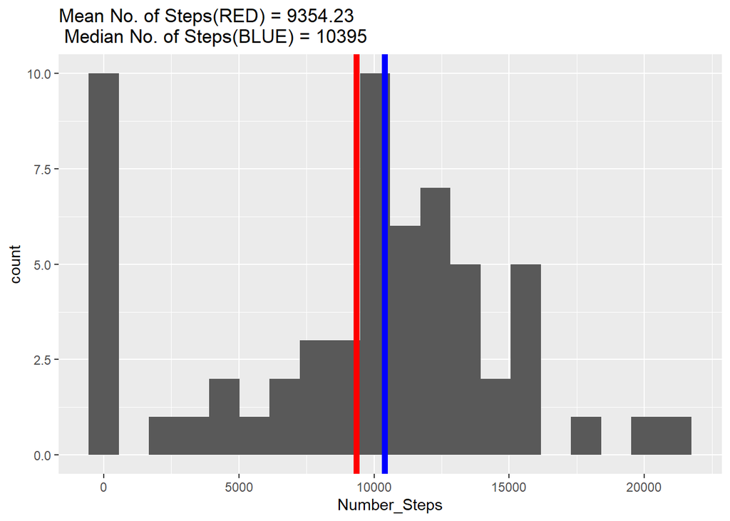

```r
Activity_SumNoSteps <- Activity_Data %>%
                      group_by(date) %>%
                      summarise(Number_Steps = sum(steps)) %>%
                     mutate(Number_Steps = ifelse(is.na(Number_Steps), 0, Number_Steps))
Mean_NoSteps <- round(mean(Activity_SumNoSteps$Number_Steps), 2)
Median_NoSteps <- median(Activity_SumNoSteps$Number_Steps)

ggplot(data=Activity_SumNoSteps, aes(x=Number_Steps)) +
    geom_histogram(bins = 20) +
    geom_vline(aes(xintercept = Mean_NoSteps),col='red',size=2) +
    geom_vline(aes(xintercept = Median_NoSteps),col='blue',size=2) +
    ggtitle( paste("Mean No. of Steps(RED) =", Mean_NoSteps,'\n',"Median No. of Steps(BLUE) =", Median_NoSteps ) )
```

## 2. What is the average daily activity pattern?

Make a time series plot (i.e. type = “l”) of the 5-minute interval (x-axis) and the average number of steps taken, averaged across all days (y-axis)

Which 5-minute interval, on average across all the days in the dataset, contains the maximum number of steps?

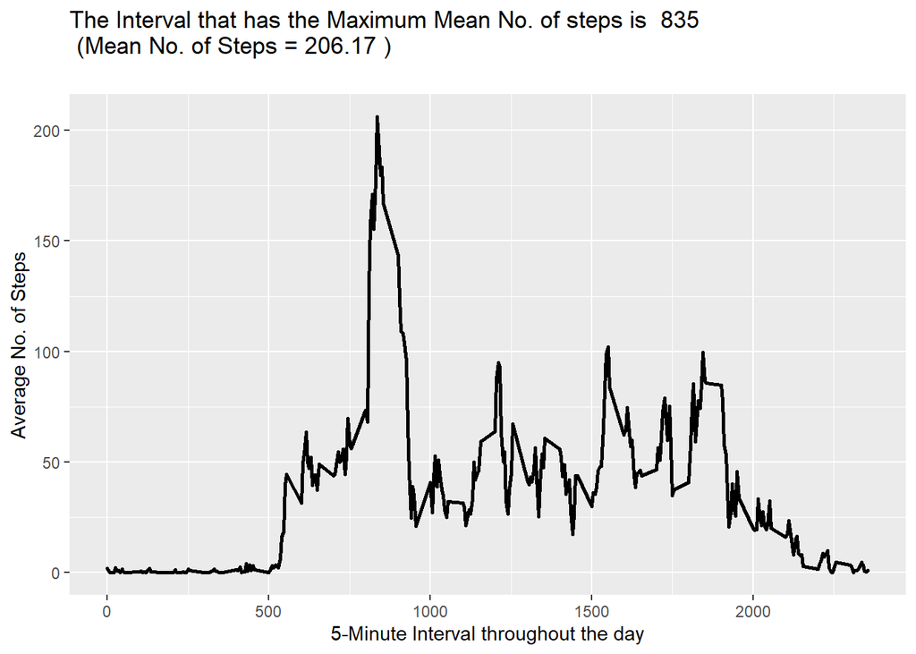

```r
Activity_MeanNoSteps <- Activity_Data %>%
  group_by(interval) %>%
  summarise(Mean_NumberSteps = mean(steps, na.rm = TRUE)) %>%
  mutate(Mean_NumberSteps = ifelse(is.na(Mean_NumberSteps), 0, Mean_NumberSteps))

Mean_NumberSteps_MAX <- max(Activity_MeanNoSteps$Mean_NumberSteps)
Mean_NumberSteps_MAX_Interval <- Activity_MeanNoSteps[Activity_MeanNoSteps$Mean_NumberSteps == Mean_NumberSteps_MAX,]$interval

ggplot(data = Activity_MeanNoSteps, aes(x = interval, y = Mean_NumberSteps)) +
geom_line(color = "black", size = 1) +
geom_point(size = 0.5) +
ggtitle( paste("The Interval that has the Maximum Mean No. of steps is ",Mean_NumberSteps_MAX_Interval,'\n'  ,"(Mean No. of Steps =", round(Mean_NumberSteps_MAX,2), ")",'\n' ) ) +
# Set the x-axis label
xlab("5-Minute Interval throughout the day") +

# Set the y-axis label
ylab("Average No. of Steps")
```

## 3. Imputing missing values

#### Calculate and report the total number of missing values in the dataset (i.e. the total number of rows with NAs)

```r
sum(is.na(Activity_Data$steps))
```

```
## [1] 2304
```

#### Devise a strategy for filling in all of the missing values in the dataset. The strategy does not need to be sophisticated. For example, you could use the mean/median for that day, or the mean for that 5-minute interval, etc.

```r
mean(Activity_Data$steps, na.rm = T)
```

```
## [1] 37.3826
```

### Fill NA by Mean

```r
Activity_Data_ImputeNAs <- Activity_Data
Activity_Data_ImputeNAs$steps[is.na(Activity_Data_ImputeNAs$steps)] <- mean(Activity_Data_ImputeNAs$steps, na.rm = T)
head(Activity_Data_ImputeNAs)
```

```
##     steps       date interval
## 1 37.3826 2012-10-01        0
## 2 37.3826 2012-10-01        5
## 3 37.3826 2012-10-01       10
## 4 37.3826 2012-10-01       15
## 5 37.3826 2012-10-01       20
## 6 37.3826 2012-10-01       25
```

#### Create a new dataset that is equal to the original dataset but with the missing data filled in.

```r
sum(is.na(Activity_Data_ImputeNAs$steps))
```

```
## [1] 0
```

#### Make a histogram of the total number of steps taken each day and Calculate and report the mean and median total number of steps taken per day.

*Please view the plot to see the values of the Mean and Median when we impute mean for NAs*

#### Do these values differ from the estimates from the first part of the assignment?

*Yes!, the values of Mean and Median after imputation are now equal compare when we haven’t perform the imputation*

#### What is the impact of imputing missing data on the estimates of the total daily number of steps?

*The effect of Imputing NAs values using mean is it transform the initial Histogram into a more normally distributed Histogram*

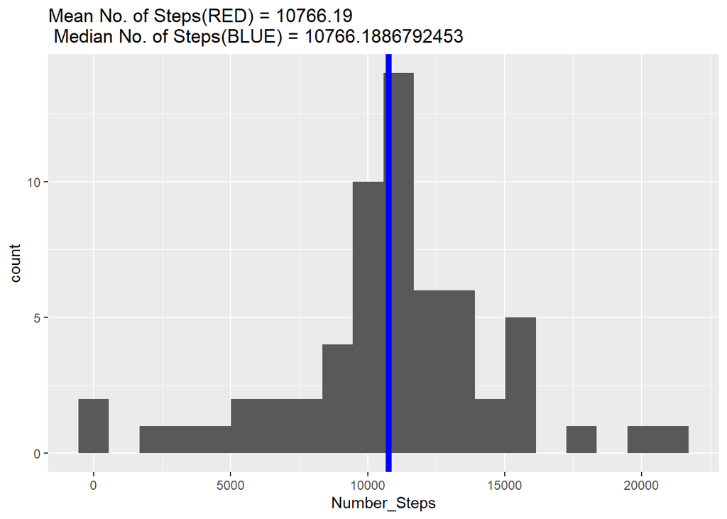

```r
Activity_SumNoSteps_ImputeNAs <- Activity_Data_ImputeNAs %>%
                      group_by(date) %>%
                      summarise(Number_Steps = sum(steps))

Mean_NoSteps <- round(mean(Activity_SumNoSteps_ImputeNAs$Number_Steps), 2)
Median_NoSteps <- median(Activity_SumNoSteps_ImputeNAs$Number_Steps)

ggplot(data=Activity_SumNoSteps_ImputeNAs, aes(x=Number_Steps)) +
    geom_histogram(bins = 20) +
    geom_vline(aes(xintercept = Mean_NoSteps),col='red',size=2) +
    geom_vline(aes(xintercept = Median_NoSteps),col='blue',size=2) +
    ggtitle( paste("Mean No. of Steps(RED) =", Mean_NoSteps,'\n',"Median No. of Steps(BLUE) =", Median_NoSteps ) )
```

## 4. Are there differences in activity patterns between weekdays and weekends?

For this part the weekdays() function may be of some help here. Use the dataset with the filled-in missing values for this part.

```r
Activity_Data_ImputeNAs <- Activity_Data_ImputeNAs %>%
  mutate(weekend = ifelse(wday(date) %in% c(1,7), "weekend", "weekday"))
Activity_Data_ImputeNAs$date <- as.Date(Activity_Data_ImputeNAs$date)
```

#### WEEKEND

```r
Activity_Data_ImputeNAs_WEND <- Activity_Data_ImputeNAs[Activity_Data_ImputeNAs["weekend"] == "weekend",]

Activity_Data_ImputeNAs_WEND_Interval <- Activity_Data_ImputeNAs_WEND %>%
  group_by(interval) %>%
  summarise(Mean_NumberSteps = mean(steps, na.rm = TRUE)) %>%
  mutate(Mean_NumberSteps = ifelse(is.na(Mean_NumberSteps), 0, Mean_NumberSteps))


WEEKEND_plot <- ggplot(data = Activity_Data_ImputeNAs_WEND_Interval, aes(x = interval, y = Mean_NumberSteps)) +
                    geom_line(color = "black", size = 1) +
                    scale_y_continuous(limits = c(0, 210)) +
                    geom_point(size = 0.5) +
                    ggtitle(paste("The distribution of Ave. No. of Steps in Weekend is very different from \n the one for Weekday ")) +
                    theme(plot.title = element_text(face = "bold")) +
                    xlab("WEEKEND: 5-Minute Interval throughout the day") +
                    ylab("Average No. of Steps")
```

#### WEEKDAY

```r
Activity_Data_ImputeNAs_WDAY <- Activity_Data_ImputeNAs[Activity_Data_ImputeNAs["weekend"] == "weekday",]

Activity_Data_ImputeNAs_WDAY_Interval <- Activity_Data_ImputeNAs_WDAY %>%
  group_by(interval) %>%
  summarise(Mean_NumberSteps = mean(steps, na.rm = TRUE)) %>%
  mutate(Mean_NumberSteps = ifelse(is.na(Mean_NumberSteps), 0, Mean_NumberSteps))

WEEKDAY_plot <- ggplot(data = Activity_Data_ImputeNAs_WDAY_Interval, aes(x = interval, y = Mean_NumberSteps)) +
                    geom_line(color = "black", size = 1) +
                    scale_y_continuous(limits = c(0, 210)) +
                    geom_point(size = 0.5) +
                    ggtitle(paste("But for the Weekday's distribution, it is very close to the overall Ave. \n No. of Steps Distribution")) +
                    theme(plot.title = element_text(face = "bold")) +
                    xlab("WEEKDAY: 5-Minute Interval throughout the day") +
                    ylab("Average No. of Steps")
```

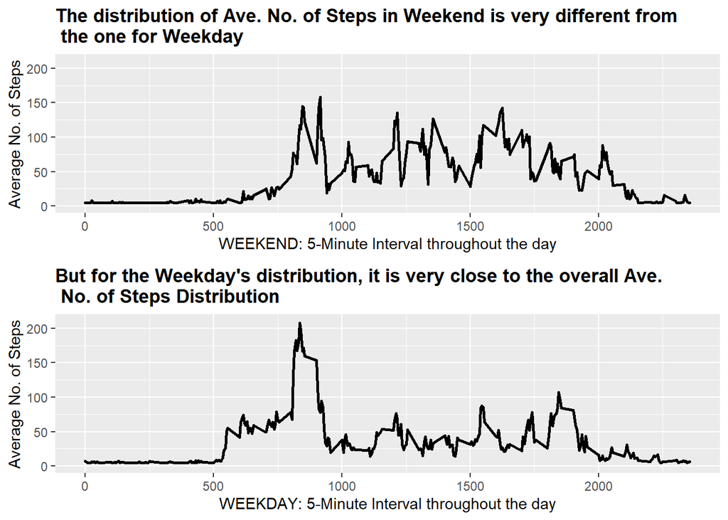

```r
# Arrange the two plots side by side
grid.arrange(WEEKEND_plot, WEEKDAY_plot,ncol = 1, nrow = 2, heights = c(4, 4))
```